# Deploy and monitor a machine learning workflow for Image Classification

Reference:https://sagemaker.readthedocs.io/en/stable/index.html

## Data Staging

We'll use a sample dataset called CIFAR to simulate the challenges Scones Unlimited are facing in Image Classification. In order to start working with CIFAR we'll need to:

1. Extract the data from a hosting service
2. Transform it into a usable shape and format
3. Load it into a production system

In other words, we're going to do some simple ETL!

### 1. Extract the data from the hosting service

In the cell below, define a function `extract_cifar_data` that extracts python version of the CIFAR-100 dataset. The CIFAR dataaset is open source and generously hosted by the University of Toronto at: https://www.cs.toronto.edu/~kriz/cifar-100-python.tar.gz

```python
# !pip install pandarallel
```

```python
import os
import time

import requests
import tqdm


def extract_cifar_data(url, filename="cifar.tar.gz"):
    """A function for extracting the CIFAR-100 dataset and storing it as a gzipped file

    Arguments:
    url      -- the URL where the dataset is hosted
    filename -- the full path where the dataset will be written

    """
###### Method 1 ######
#     r = requests.get(url)
#     with open(filename, "wb") as file_context:
#         file_context.write(r.content)
#     return

###### Method 2 ######
    try:
        response = requests.get(url, stream=True)
        assert response.status_code == 200
    except Exception:
        raise
    else:
        file = os.path.join(save_loc, filename)
        with tqdm.wrapattr(
            open(file, 'wb'), 'write',
            unit='B', unit_scale=True, unit_divisor=1024, mniters=1,
            desc=filename, total=int(response.headers.get('content-length', 0))
        ) as fout:
            for chunk in response.iter_content(chunk_size=4096):
                fout.write(chunk)
```

Let's test it out! Run the following cell and check whether a new file `cifar.tar.gz` is created in the file explorer.

```python
extract_cifar_data("https://www.cs.toronto.edu/~kriz/cifar-100-python.tar.gz")
```

### 2. Transform the data into a usable shape and format

Clearly, distributing the data as a gzipped archive makes sense for the hosting service! It saves on bandwidth, storage, and it's a widely-used archive format. In fact, it's so widely used that the Python community ships a utility for working with them, `tarfile`, as part of its Standard Library. Execute the following cell to decompress your extracted dataset:

```python
import tarfile

with tarfile.open("cifar.tar.gz", "r:gz") as tar:
    tar.extractall()
```

A new folder `cifar-100-python` should be created, containing `meta`, `test`, and `train` files. These files are `pickles` and the [CIFAR homepage](https://www.cs.toronto.edu/~kriz/cifar.html) provides a simple script that can be used to load them. We've adapted the script below for you to run:

```python
import pickle

with open("./cifar-100-python/meta", "rb") as f:
    dataset_meta = pickle.load(f, encoding='bytes')

with open("./cifar-100-python/test", "rb") as f:
    dataset_test = pickle.load(f, encoding='bytes')

with open("./cifar-100-python/train", "rb") as f:
    dataset_train = pickle.load(f, encoding='bytes')
```

```python
# Feel free to explore the datasets

dataset_train.keys()
```

```
dict_keys([b'filenames', b'batch_label', b'fine_labels', b'coarse_labels', b'data'])
```

```python
32*32*3
```

```
3072
```

For a simple gut-check, let's transform one of our images. Each 1024 items in a row is a channel (red, green, then blue). Each 32 items in the channel are a row in the 32x32 image. Using python, we can stack these channels into a 32x32x3 array, and save it as a PNG file:

```python
import numpy as np

# Each 1024 in a row is a channel (red, green, then blue)
row = dataset_train[b'data'][0]
red, green, blue = row[0:1024], row[1024:2048], row[2048:]

# Each 32 items in the channel are a row in the 32x32 image
red = red.reshape(32,32)
green = green.reshape(32,32)
blue = blue.reshape(32,32)

# Combine the channels into a 32x32x3 image!
combined = np.dstack((red,green,blue))
```

For a more concise version, consider the following:

```python
# All in one:
test_image = np.dstack((
    row[0:1024].reshape(32,32),
    row[1024:2048].reshape(32,32),
    row[2048:].reshape(32,32)
))
```

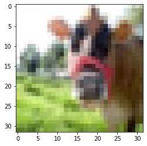

```python
import matplotlib.pyplot as plt
plt.imshow(test_image);
```

Looks like a cow! Let's check the label. `dataset_meta` contains label names in order, and `dataset_train` has a list of labels for each row.

```python
dataset_train[b'fine_labels'][0]
```

```
19
```

Our image has a label of `19`, so let's see what the 19th item is in the list of label names.

```python
print(dataset_meta[b'fine_label_names'][19])
```

```
b'cattle'
```

Ok! 'cattle' sounds about right. By the way, using the previous two lines we can do:

```python
n = 0
print(dataset_meta[b'fine_label_names'][dataset_train[b'fine_labels'][n]])
```

```
b'cattle'
```

Now we know how to check labels, is there a way that we can also check file names? `dataset_train` also contains a `b'filenames'` key. Let's see what we have here:

```python
print(dataset_train[b'filenames'][0])
```

```
b'bos_taurus_s_000507.png'
```

"Taurus" is the name of a subspecies of cattle, so this looks like a pretty reasonable filename. To save an image we can also do:

```python
plt.imsave("file.png", test_image)
```

Your new PNG file should now appear in the file explorer -- go ahead and pop it open to see!

Now that you know how to reshape the images, save them as files, and capture their filenames and labels, let's just capture all the bicycles and motorcycles and save them. Scones Unlimited can use a model that tells these apart to route delivery drivers automatically.

In the following cell, identify the label numbers for Bicycles and Motorcycles:

```python
import pandas as pd

# Filter the dataset_train and dataset_meta objects to find the label numbers for Bicycle and Motorcycles
set([label_num for label_num in dataset_train[b'fine_labels'] if dataset_meta[b'fine_label_names'][label_num] in [b'bicycle', b'motorcycle']])
```

```
{8, 48}
```

Good job! We only need objects with label 8 and 48 -- this drastically simplifies our handling of the data! Below we construct a dataframe for you, and you can safely drop the rows that don't contain observations about bicycles and motorcycles. Fill in the missing lines below to drop all other rows:

```python
#Construct the dataframe
df_train = pd.DataFrame({
    "filenames": dataset_train[b'filenames'],
    "labels": dataset_train[b'fine_labels'],
    "row": range(len(dataset_train[b'filenames']))
})

# # Drop all rows from df_train where label is not 8 or 48
df_train = df_train[df_train.labels.isin([8, 48])]

# Decode df_train.filenames so they are regular strings
df_train["filenames"] = df_train["filenames"].apply(
    lambda x: x.decode("utf-8")
)


df_test = pd.DataFrame({
    "filenames": dataset_test[b'filenames'],
    "labels": dataset_test[b'fine_labels'],
    "row": range(len(dataset_test[b'filenames']))
})

# Drop all rows from df_test where label is not 8 or 48
df_test = df_test[df_test.labels.isin([8, 48])]

# Decode df_test.filenames so they are regular strings
df_test["filenames"] = df_test["filenames"].apply(
    lambda x: x.decode("utf-8")
)
```

```python
df_test
```

|  | filenames | labels | row |
| --- | --- | --- | --- |
| 27 | safety_bike_s_000390.png | 8 | 27 |
| 28 | bike_s_000658.png | 8 | 28 |
| 116 | velocipede_s_001744.png | 8 | 116 |
| 161 | bike_s_000643.png | 8 | 161 |
| 319 | ordinary_bicycle_s_000437.png | 8 | 319 |
| ... | ... | ... | ... |
| 9654 | trail_bike_s_000073.png | 48 | 9654 |
| 9692 | bike_s_000941.png | 8 | 9692 |
| 9833 | motorcycle_s_000141.png | 48 | 9833 |
| 9928 | ordinary_bicycle_s_000105.png | 8 | 9928 |
| 9939 | bicycle_s_001218.png | 8 | 9939 |

200 rows × 3 columns

Now that the data is filtered for just our classes, we can save all our images.

```python
!mkdir ./train
!mkdir ./test
```

In the previous sections we introduced you to several key snippets of code:

1. Grabbing the image data:

```
dataset_train[b'data'][0]
```

1. A simple idiom for stacking the image data into the right shape

```
import numpy as np
np.dstack((
    row[0:1024].reshape(32,32),
    row[1024:2048].reshape(32,32),
    row[2048:].reshape(32,32)
))
```

1. A simple `matplotlib` utility for saving images

```
plt.imsave(path+row['filenames'], target)
```

Compose these together into a function that saves all the images into the `./test` and `./train` directories. Use the comments in the body of the `save_images` function below to guide your construction of the function:

```python
# ## Method 1
# def save_images(dataset, root_dir, original_data):
#     #Grab the image data in row-major form
#     for i in range(len(dataset)):

#         row = dataset['row'].iloc[i]

#         filename = dataset['filenames'].iloc[i]

#         pix_matrix = original_data[b'data'][row]

#         # Consolidated stacking/reshaping from earlier
#         target = np.dstack((
#             pix_matrix[0:1024].reshape(32,32),
#             pix_matrix[1024:2048].reshape(32,32),
#             pix_matrix[2048:].reshape(32,32)
#         ))

#         # Save the image
#         plt.imsave(os.path.join(root_dir, filename), target)

#     # Return any signal data you want for debugging
#     return

# ## save ALL images using the save_images function
# save_images(df_train, './train/', dataset_train)
# save_images(df_test, './test/', dataset_test)
```

```python
# Method 2
# Better one

from pandarallel import pandarallel

pandarallel.initialize(nb_workers=2, progress_bar=True, use_memory_fs=True)

data = {
    'train_df': df_train,
    'train_dataset': dataset_train,
    'test_df': df_test,
    'test_dataset': dataset_test
}

def save_images(row, batch, dataset):
    file_path = os.path.join(batch, row.filenames)
    arr = dataset[row.row]

    target = np.dstack((
            arr[0:1024].reshape(32,32),
            arr[1024:2048].reshape(32,32),
            arr[2048:].reshape(32,32)
    ))

    plt.imsave(file_path, target)

for batch in ('test', 'train'):
    _ = data[f"{batch}_df"].parallel_apply(
        save_images,
        batch=f'./{batch}',
        dataset=data[f'{batch}_dataset'][b'data'],
        axis=1
    )
```

```
INFO: Pandarallel will run on 2 workers.
INFO: Pandarallel will use Memory file system to transfer data between the main process and workers.
```

### 3. Load the data

Now we can load the data into S3.

Using the sagemaker SDK grab the current region, execution role, and bucket.

```python
import boto3
my_session = boto3.session.Session()
my_region = my_session.region_name
```

```python
import sagemaker

session = sagemaker.Session()

bucket= session.default_bucket()
print("Default Bucket: {}".format(bucket))

region =  boto3.session.Session().region_name
print("AWS Region: {}".format(region))

role = sagemaker.get_execution_role()
print("RoleArn: {}".format(role))
```

```
Default Bucket: sagemaker-ap-southeast-1-263436898058
AWS Region: ap-southeast-1
RoleArn: arn:aws:iam::263436898058:role/trustcodes-ml
```

With this data we can easily sync your data up into S3!

```python
import os

os.environ["DEFAULT_S3_BUCKET"] = bucket
!aws s3 sync ./train s3://${DEFAULT_S3_BUCKET}/train/
!aws s3 sync ./test s3://${DEFAULT_S3_BUCKET}/test/
```

[output not shown]

[output cut: 1145 more lines]

[output not shown]

And that's it! You can check the bucket and verify that the items were uploaded.

## Model Training

For Image Classification, Sagemaker [also expects metadata](https://docs.aws.amazon.com/sagemaker/latest/dg/image-classification.html) e.g. in the form of TSV files with labels and filepaths. We can generate these using our Pandas DataFrames from earlier:

```python
def to_metadata_file(df, prefix):
    df["s3_path"] = df["filenames"]
    df["labels"] = df["labels"].apply(lambda x: 0 if x==8 else 1)
    return df[["row", "labels", "s3_path"]].to_csv(
        f"{prefix}.lst", sep="\t", index=False, header=False
    )

to_metadata_file(df_train.copy(), "train")
to_metadata_file(df_test.copy(), "test")
```

We can also upload our manifest files:

```python
import boto3

# Upload files
boto3.Session().resource('s3').Bucket(
    bucket).Object('train.lst').upload_file('./train.lst')
boto3.Session().resource('s3').Bucket(
    bucket).Object('test.lst').upload_file('./test.lst')
```

Using the `bucket` and `region` info we can get the latest prebuilt container to run our training job, and define an output location on our s3 bucket for the model. Use the `image_uris` function from the SageMaker SDK to retrieve the latest `image-classification` image below:

```python
# Use the image_uris function to retrieve the latest 'image-classification' image
algo_image = sagemaker.image_uris.retrieve(framework="image-classification", region=region, version="latest")
s3_output_location = f"s3://{bucket}/models/image_model"
```

```
Defaulting to the only supported framework/algorithm version: 1. Ignoring framework/algorithm version: latest.
```

We're ready to create an estimator! Create an estimator `img_classifier_model` that uses one instance of `ml.p2.xlarge`. Ensure that y ou use the output location we defined above - we'll be referring to that later!

```python
# Reference:
# https://sagemaker.readthedocs.io/en/stable/api/training/estimators.html

img_classifier_model=sagemaker.estimator.Estimator(
    algo_image,
    role,
    instance_count=1,
    instance_type="ml.p2.xlarge",
    output_path=s3_output_location,
    sagemaker_session=session
)
```

We can also set a few key hyperparameters and define the inputs for our model:

```python
# img_classifier_model.set_hyperparameters(
#     image_shape='3,32,32',
#     num_classes='2',
#     num_training_samples= len(df_train)
# )


labelled_obj = [8, 48]
img_classifier_model.set_hyperparameters(
    image_shape="3,32,32",
    num_classes=str(len(labelled_obj)),
    num_training_samples=str(len(os.listdir('train'))),
    learning_rate=0.05,
    mini_batch_size=16
)
```

The `image-classification` image uses four input channels with very specific input parameters. For convenience, we've provided them below:

```python
from sagemaker.debugger import Rule, rule_configs
from sagemaker.session import TrainingInput
model_inputs = {
        "train": sagemaker.inputs.TrainingInput(
            s3_data=f"s3://{bucket}/train/",
            content_type="application/x-image"
        ),
        "validation": sagemaker.inputs.TrainingInput(
            s3_data=f"s3://{bucket}/test/",
            content_type="application/x-image"
        ),
        "train_lst": sagemaker.inputs.TrainingInput(
            s3_data=f"s3://{bucket}/train.lst",
            content_type="application/x-image"
        ),
        "validation_lst": sagemaker.inputs.TrainingInput(
            s3_data=f"s3://{bucket}/test.lst",
            content_type="application/x-image"
        )
}
```

Great, now we can train the model using the model_inputs. In the cell below, call the `fit` method on our model,:

```python
img_classifier_model.fit(model_inputs)
```

```
2022-04-06 23:15:36 Starting - Starting the training job...
2022-04-06 23:16:01 Starting - Preparing the instances for trainingProfilerReport-1649286935: InProgress
.........
2022-04-06 23:17:30 Downloading - Downloading input data......
2022-04-06 23:18:30 Training - Downloading the training image........Docker entrypoint called with argument(s): train

2022-04-06 23:19:51 Training - Training image download completed. Training in progress.[04/06/2022 23:19:53 INFO 140191539521344] Reading default configuration from /opt/amazon/lib/python3.7/site-packages/image_classification/default-input.json: {'use_pretrained_model': 0, 'num_layers': 152, 'epochs…
[04/06/2022 23:19:53 INFO 140191539521344] Merging with provided configuration from /opt/ml/input/config/hyperparameters.json: {'image_shape': '3,32,32', 'learning_rate': '0.05', 'mini_batch_size': '16', 'num_classes': '2', 'num_training_samples': '1000'}
[04/06/2022 23:19:53 INFO 140191539521344] Final configuration: {'use_pretrained_model': 0, 'num_layers': 152, 'epochs': 30, 'learning_rate': '0.05', 'lr_scheduler_factor': 0.1, 'optimizer': 'sgd', 'momentum': 0, 'weight_decay': 0.0001, 'beta_1': 0.9, 'beta_2': 0.999, 'eps': 1e-08, 'gamma': 0.9, 'mi…
[04/06/2022 23:19:53 INFO 140191539521344] Searching for .lst files in /opt/ml/input/data/train_lst.
[04/06/2022 23:19:53 INFO 140191539521344] Creating record files for train.lst
[04/06/2022 23:19:54 INFO 140191539521344] Done creating record files...
[04/06/2022 23:19:54 INFO 140191539521344] Searching for .lst files in /opt/ml/input/data/validation_lst.
[04/06/2022 23:19:54 INFO 140191539521344] Creating record files for test.lst
[04/06/2022 23:19:54 INFO 140191539521344] Done creating record files...
[04/06/2022 23:19:54 INFO 140191539521344] use_pretrained_model: 0
[04/06/2022 23:19:54 INFO 140191539521344] multi_label: 0
[04/06/2022 23:19:54 INFO 140191539521344] Performing random weight initialization
[04/06/2022 23:19:54 INFO 140191539521344] ---- Parameters ----
[04/06/2022 23:19:54 INFO 140191539521344] num_layers: 152
[04/06/2022 23:19:54 INFO 140191539521344] data type: <class 'numpy.float32'>
[04/06/2022 23:19:54 INFO 140191539521344] epochs: 30
[04/06/2022 23:19:54 INFO 140191539521344] optimizer: sgd
[04/06/2022 23:19:54 INFO 140191539521344] momentum: 0.9
[04/06/2022 23:19:54 INFO 140191539521344] weight_decay: 0.0001
[04/06/2022 23:19:54 INFO 140191539521344] learning_rate: 0.05
[04/06/2022 23:19:54 INFO 140191539521344] num_training_samples: 1000
[04/06/2022 23:19:54 INFO 140191539521344] mini_batch_size: 16
[04/06/2022 23:19:54 INFO 140191539521344] image_shape: 3,32,32
[04/06/2022 23:19:54 INFO 140191539521344] num_classes: 2
[04/06/2022 23:19:54 INFO 140191539521344] augmentation_type: None
[04/06/2022 23:19:54 INFO 140191539521344] kv_store: device
[04/06/2022 23:19:54 INFO 140191539521344] checkpoint_frequency not set, will store the best model
[04/06/2022 23:19:54 INFO 140191539521344] --------------------
[04/06/2022 23:19:54 INFO 140191539521344] Setting number of threads: 3
[23:20:03] /opt/brazil-pkg-cache/packages/AIAlgorithmsMXNet/AIAlgorithmsMXNet-1.3.x_ecl_Cuda_10.1.x.11282.0/AL2_x86_64/generic-flavor/src/src/operator/nn/./cudnn/./cudnn_algoreg-inl.h:97: Running performance tests to find the best convolution algorithm, this can take a while... (setting env variable…
[04/06/2022 23:20:20 INFO 140191539521344] Epoch[0] Batch [20]#011Speed: 18.951 samples/sec#011accuracy=0.541667
[04/06/2022 23:20:27 INFO 140191539521344] Epoch[0] Batch [40]#011Speed: 27.026 samples/sec#011accuracy=0.528963
[04/06/2022 23:20:33 INFO 140191539521344] Epoch[0] Batch [60]#011Speed: 31.458 samples/sec#011accuracy=0.566598
[04/06/2022 23:20:34 INFO 140191539521344] Epoch[0] Train-accuracy=0.567540
```

[output cut: 46 more lines]

```
[04/06/2022 23:31:38 INFO 140191539521344] Epoch[28] Train-accuracy=0.989919
[04/06/2022 23:31:38 INFO 140191539521344] Epoch[28] Time cost=20.992
[04/06/2022 23:31:39 INFO 140191539521344] Epoch[28] Validation-accuracy=0.848958
[04/06/2022 23:31:47 INFO 140191539521344] Epoch[29] Batch [20]#011Speed: 45.840 samples/sec#011accuracy=0.994048
[04/06/2022 23:31:54 INFO 140191539521344] Epoch[29] Batch [40]#011Speed: 46.352 samples/sec#011accuracy=0.995427
[04/06/2022 23:32:01 INFO 140191539521344] Epoch[29] Batch [60]#011Speed: 46.473 samples/sec#011accuracy=0.996926
[04/06/2022 23:32:01 INFO 140191539521344] Epoch[29] Train-accuracy=0.996976
[04/06/2022 23:32:01 INFO 140191539521344] Epoch[29] Time cost=21.002
[04/06/2022 23:32:03 INFO 140191539521344] Epoch[29] Validation-accuracy=0.836538

2022-04-06 23:32:10 Uploading - Uploading generated training model
2022-04-06 23:33:02 Completed - Training job completed
ProfilerReport-1649286935: IssuesFound
Training seconds: 923
Billable seconds: 923
```

If all goes well, you'll end up with a model topping out above `.8` validation accuracy. With only 1000 training samples in the CIFAR dataset, that's pretty good. We could definitely pursue data augmentation & gathering more samples to help us improve further, but for now let's proceed to deploy our model.

### Getting ready to deploy

To begin with, let's configure Model Monitor to track our deployment. We'll define a `DataCaptureConfig` below:

```python
from sagemaker.model_monitor import DataCaptureConfig

data_capture_config = DataCaptureConfig(
    enable_capture=True,
    sampling_percentage=100,
    destination_s3_uri=f"s3://{bucket}/data_capture",
    sagemaker_session=session,
)
```

Note the `destination_s3_uri` parameter: At the end of the project, we can explore the `data_capture` directory in S3 to find crucial data about the inputs and outputs Model Monitor has observed on our model endpoint over time.

With that done, deploy your model on a single `ml.m5.xlarge` instance with the data capture config attached:

```python
from time import gmtime, strftime

# timestamp = strftime("%Y-%m-%d %H:%M:%S", gmtime())
timestamp = strftime("%Y-%m-%d", gmtime())
endpoint_name = f"scones-bicycle-motorcycle-classifier-{timestamp}"

deployment = img_classifier_model.deploy(
    initial_instance_count=1,
    instance_type='ml.m5.xlarge',
    data_capture_config=data_capture_config,
    endpoint_name=endpoint_name
)

endpoint = deployment.endpoint_name
print(endpoint)
```

```
---------------!scones-bicycle-motorcycle-classifier-2022-04-07
```

Note the endpoint name for later as well.

Next, instantiate a Predictor:

```python
from sagemaker.predictor import Predictor

predictor = Predictor(
    endpoint_name = endpoint,
    sagemaker_session = session
)
```

In the code snippet below we are going to prepare one of your saved images for prediction. Use the predictor to process the `payload`.

```python
from sagemaker.serializers import IdentitySerializer
import base64

predictor.serializer = IdentitySerializer("image/png")
with open("./test/bicycle_s_001789.png", "rb") as f:
    payload = f.read()
```

```python
inference = predictor.predict(payload)
```

Your `inference` object is an array of two values, the predicted probability value for each of your classes (bicycle and motorcycle respectively.) So, for example, a value of `b'[0.91, 0.09]'` indicates the probability of being a bike is 91% and being a motorcycle is 9%.

```python
print(inference)
```

```
b'[0.9992095232009888, 0.0007903929799795151]'
```

```python
print(inference)
```

[output not shown]

```python
filePath = './test/'
image_arr = os.listdir(filePath)


for i in image_arr:
    cur_file = f'./test/{i}'
    with open(cur_file, "rb") as f:
        payload = f.read()
        inference = predictor.predict(payload)
        print(i, inference)
```

```
motorbike_s_000135.png b'[0.008231261745095253, 0.9917687177658081]'
bicycle_s_001107.png b'[0.9907989501953125, 0.009201028384268284]'
motorcycle_s_001348.png b'[0.0003992460551671684, 0.9996008276939392]'
bicycle_s_001047.png b'[0.24678407609462738, 0.7532159090042114]'
safety_bicycle_s_001153.png b'[0.22941873967647552, 0.7705813050270081]'
motorcycle_s_000352.png b'[1.4199360975908348e-07, 0.9999998807907104]'
motorbike_s_000126.png b'[0.8405784368515015, 0.15942153334617615]'
motorcycle_s_001519.png b'[0.034547120332717896, 0.9654529094696045]'
safety_bike_s_000699.png b'[0.9984367489814758, 0.0015632914146408439]'
bicycle_s_001102.png b'[0.9999065399169922, 9.350154869025573e-05]'
velocipede_s_001335.png b'[0.9999934434890747, 6.537487479363335e-06]'
bicycle_s_000513.png b'[0.9999551773071289, 4.479528433876112e-05]'
velocipede_s_000001.png b'[0.9987389445304871, 0.0012611036654561758]'
bicycle_s_000977.png b'[0.9994903802871704, 0.0005096413660794497]'
motorcycle_s_000427.png b'[6.723653456219836e-08, 0.9999998807907104]'
bicycle_s_000030.png b'[0.9958797693252563, 0.004120186436921358]'
trail_bike_s_000073.png b'[0.0002221427421318367, 0.9997778534889221]'
minibike_s_000052.png b'[4.670373891713098e-05, 0.9999532699584961]'
motorbike_s_000005.png b'[0.0003261042002122849, 0.9996739625930786]'
motorcycle_s_000878.png b'[0.20560909807682037, 0.794390857219696]'
moped_s_000306.png b'[0.016522753983736038, 0.9834772944450378]'
minibike_s_000828.png b'[0.8164422512054443, 0.1835576891899109]'
velocipede_s_000863.png b'[0.9994644522666931, 0.0005355824832804501]'
cycle_s_001297.png b'[0.9858492612838745, 0.014150703325867653]'
cycle_s_001915.png b'[0.8855897188186646, 0.11441025882959366]'
minibike_s_000792.png b'[0.06554242968559265, 0.9344576001167297]'
motorcycle_s_000007.png b'[1.2800883882960732e-15, 1.0]'
safety_bicycle_s_001322.png b'[0.9998213648796082, 0.00017869984731078148]'
velocipede_s_001232.png b'[0.9999995231628418, 5.084427243673417e-07]'
minibike_s_000947.png b'[0.018721776083111763, 0.9812782406806946]'
motorcycle_s_000963.png b'[1.525052192819995e-13, 1.0]'
bike_s_002009.png b'[0.9998373985290527, 0.00016256920935120434]'
moped_s_000007.png b'[2.2299731426755898e-05, 0.999977707862854]'
motorcycle_s_000530.png b'[0.00015246696420945227, 0.9998475313186646]'
minibike_s_001732.png b'[0.00017763722280506045, 0.9998224377632141]'
bike_s_001852.png b'[0.9946528673171997, 0.005347149912267923]'
motorcycle_s_000485.png b'[0.005635411944240332, 0.9943646192550659]'
ordinary_bicycle_s_000105.png b'[0.9999890327453613, 1.0953332093777135e-05]'
motorcycle_s_001687.png b'[4.329486769094615e-10, 1.0]'
bike_s_002208.png b'[0.42731374502182007, 0.5726862549781799]'
```

[output cut: 145 more lines]

```
bike_s_000131.png b'[0.9996294975280762, 0.00037046708166599274]'
velocipede_s_001379.png b'[2.723871375565068e-06, 0.9999972581863403]'
safety_bike_s_001087.png b'[0.9958482980728149, 0.004151712637394667]'
motorcycle_s_000615.png b'[0.003266491461545229, 0.996733546257019]'
bike_s_000658.png b'[0.10612949728965759, 0.89387047290802]'
minibike_s_001651.png b'[5.10771599238069e-07, 0.9999995231628418]'
minibike_s_000288.png b'[0.00021242140792310238, 0.9997876286506653]'
ordinary_bicycle_s_000158.png b'[0.9999518394470215, 4.817260196432471e-05]'
bike_s_000643.png b'[0.9999849796295166, 1.497405355621595e-05]'
safety_bike_s_000438.png b'[0.9988969564437866, 0.0011030319146811962]'
minibike_s_002051.png b'[2.2111217390374804e-07, 0.9999997615814209]'
motorcycle_s_000042.png b'[0.22572122514247894, 0.7742787599563599]'
bike_s_000163.png b'[0.1970607042312622, 0.8029392957687378]'
minibike_s_000497.png b'[0.9699969291687012, 0.030003070831298828]'
motorcycle_s_001892.png b'[0.08719310164451599, 0.9128069281578064]'
```

### Draft Lambdas and Step Function Workflow

Your operations team uses Step Functions to orchestrate serverless workflows. One of the nice things about Step Functions is that [workflows can call other workflows](https://docs.aws.amazon.com/step-functions/latest/dg/connect-stepfunctions.html), so the team can easily plug your workflow into the broader production architecture for Scones Unlimited.

In this next stage you're going to write and deploy three Lambda functions, and then use the Step Functions visual editor to chain them together! Our functions are going to work with a simple data object:

```
{
    "inferences": [], # Output of predictor.predict
    "s3_key": "", # Source data S3 key
    "s3_bucket": "", # Source data S3 bucket
    "image_data": ""  # base64 encoded string containing the image data
}
```

A good test object that you can use for Lambda tests and Step Function executions, throughout the next section, might look like this:

```
{
  "image_data": "",
  "s3_bucket": MY_BUCKET_NAME, # Fill in with your bucket
  "s3_key": "test/bicycle_s_000513.png"
}
```

Using these fields, your functions can read and write the necessary data to execute your workflow. Let's start with the first function. Your first Lambda function will copy an object from S3, base64 encode it, and then return it to the step function as `image_data` in an event.

Go to the Lambda dashboard and create a new Lambda function with a descriptive name like "serializeImageData" and select thr 'Python 3.8' runtime. Add the same permissions as the SageMaker role you created earlier. (Reminder: you do this in the Configuration tab under "Permissions"). Once you're ready, use the starter code below to craft your Lambda handler:

```
import json
import boto3
import base64

s3 = boto3.client('s3')

def lambda_handler(event, context):
    """A function to serialize target data from S3"""

    # Get the s3 address from the Step Function event input
    key = ## TODO: fill in
    bucket = ## TODO: fill in

    # Download the data from s3 to /tmp/image.png
    ## TODO: fill in

    # We read the data from a file
    with open("/tmp/image.png", "rb") as f:
        image_data = base64.b64encode(f.read())

    # Pass the data back to the Step Function
    print("Event:", event.keys())
    return {
        'statusCode': 200,
        'body': {
            "image_data": image_data,
            "s3_bucket": bucket,
            "s3_key": key,
            "inferences": []
        }
    }
```

The next function is responsible for the classification part - we're going to take the image output from the previous function, decode it, and then pass inferences back to the the Step Function.

Because this Lambda will have runtime dependencies (i.e. the SageMaker SDK) you'll need to package them in your function. *Key reading:* https://docs.aws.amazon.com/lambda/latest/dg/python-package-create.html#python-package-create-with-dependency

Create a new Lambda function with the same rights and a descriptive name, then fill in the starter code below for your classifier Lambda.

```
import json
import sagemaker
import base64
from sagemaker.serializers import IdentitySerializer

# Fill this in with the name of your deployed model
ENDPOINT = ## TODO: fill in

def lambda_handler(event, context):

    # Decode the image data
    image = base64.b64decode(## TODO: fill in)

    # Instantiate a Predictor
    predictor = ## TODO: fill in

    # For this model the IdentitySerializer needs to be "image/png"
    predictor.serializer = IdentitySerializer("image/png")

    # Make a prediction:
    inferences = ## TODO: fill in

    # We return the data back to the Step Function
    event["inferences"] = inferences.decode('utf-8')
    return {
        'statusCode': 200,
        'body': json.dumps(event)
    }
```

Finally, we need to filter low-confidence inferences. Define a threshold between 1.00 and 0.000 for your model: what is reasonble for you? If the model predicts at `.70` for it's highest confidence label, do we want to pass that inference along to downstream systems? Make one last Lambda function and tee up the same permissions:

```
import json


THRESHOLD = .93


def lambda_handler(event, context):

    # Grab the inferences from the event
    inferences = ## TODO: fill in

    # Check if any values in our inferences are above THRESHOLD
    meets_threshold = ## TODO: fill in

    # If our threshold is met, pass our data back out of the
    # Step Function, else, end the Step Function with an error
    if meets_threshold:
        pass
    else:
        raise("THRESHOLD_CONFIDENCE_NOT_MET")

    return {
        'statusCode': 200,
        'body': json.dumps(event)
    }
```

Once you have tested the lambda functions, save the code for each lambda function in a python script called 'lambda.py'.

With your lambdas in place, you can use the Step Functions visual editor to construct a workflow that chains them together. In the Step Functions console you'll have the option to author a Standard step function *Visually*.

When the visual editor opens, you'll have many options to add transitions in your workflow. We're going to keep it simple and have just one: to invoke Lambda functions. Add three of them chained together. For each one, you'll be able to select the Lambda functions you just created in the proper order, filter inputs and outputs, and give them descriptive names.

Make sure that you:

1. Are properly filtering the inputs and outputs of your invokations (e.g. `$.body`)
2. Take care to remove the error handling from the last function - it's supposed to "fail loudly" for your operations colleagues!

Take a screenshot of your working step function in action and export the step function as JSON for your submission package.

Great! Now you can use the files in `./test` as test files for our workflow. Depending on our threshold, our workflow should reliably pass predictions about images from `./test` on to downstream systems, while erroring out for inferences below our confidence threshold!